# Summarizing data practice

AJ Irwin

2024-02-01

From slides

```r
ChickWeight |>
  group_by(Chick) |>
  mutate(growth = (weight-min(weight)) / Time)
```

```
## # A tibble: 578 × 5
## # Groups:   Chick [50]
##    weight  Time Chick Diet  growth
##     <dbl> <dbl> <ord> <fct>  <dbl>
##  1     42     0 1     1     NaN
##  2     51     2 1     1       4.5
##  3     59     4 1     1       4.25
##  4     64     6 1     1       3.67
##  5     76     8 1     1       4.25
##  6     93    10 1     1       5.1
##  7    106    12 1     1       5.33
##  8    125    14 1     1       5.93
##  9    149    16 1     1       6.69
## 10    171    18 1     1       7.17
## # ℹ 568 more rows
```

Try single = for logical comparison and see what happens!

```r
ChickWeight |>
  filter(Time == 10) |>
  group_by(Diet) |>
  summarize(weight_10 = mean(weight), .groups = "drop")
```

```
## # A tibble: 4 × 2
##   Diet  weight_10
##   <fct>     <dbl>
## 1 1          93.1
## 2 2         108.
## 3 3         117.
## 4 4         126
```

Use the dplyr functions: mutate, filter, group_by, summarize, select, arrange to answer the following questions.

- How many kinds of species of penguin are in the dataset `penguins`? How many observations of each species?

```r
penguins |> count(species)
```

```
## # A tibble: 3 × 2
##   species       n
##   <fct>     <int>
## 1 Adelie      152
## 2 Chinstrap    68
## 3 Gentoo      124
```

- What is the maximum and minimum flipper length?

```r
penguins |> summarize(max_flipper = max(flipper_length_mm),
                      min_flipper = min(flipper_length_mm))
```

```
## # A tibble: 1 × 2
##   max_flipper min_flipper
##         <int>       <int>
## 1          NA          NA
```

```r
penguins |> summarize(max_flipper = max(flipper_length_mm, na.rm=TRUE),
                      min_flipper = min(flipper_length_mm, na.rm=TRUE),
                      count = n())
```

```
## # A tibble: 1 × 3
##   max_flipper min_flipper count
##         <int>       <int> <int>
## 1         231         172   344
```

- Use `na.omit` and `filter(!is.na())` to remove missing data.

```r
penguins |> filter(!is.na(flipper_length_mm)) |>
  summarize(max_flipper = max(flipper_length_mm),
            min_flipper = min(flipper_length_mm),
            count = n())
```

```
## # A tibble: 1 × 3
##   max_flipper min_flipper count
##         <int>       <int> <int>
## 1         231         172   342
```

```r
penguins |> na.omit() |>
  summarize(max_flipper = max(flipper_length_mm),
            min_flipper = min(flipper_length_mm),
            count = n())
```

```
## # A tibble: 1 × 3
##   max_flipper min_flipper count
##         <int>       <int> <int>
## 1         231         172   333
```

- Find the max and min flipper length for each species.

```r
penguins |> filter(!is.na(flipper_length_mm)) |>
  group_by(species, sex) |>
  summarize(max_flipper = max(flipper_length_mm),
            median_flipper = median(flipper_length_mm),
            min_flipper = min(flipper_length_mm),
            count = n())
```

```
## # A tibble: 8 × 6
## # Groups:   species [3]
##   species   sex    max_flipper median_flipper min_flipper count
##   <fct>     <fct>        <int>          <dbl>       <int> <int>
## 1 Adelie    female         202           188          172    73
## 2 Adelie    male           210           193          178    73
## 3 Adelie    <NA>           193           186          179     5
## 4 Chinstrap female         202           192          178    34
## 5 Chinstrap male           212           200.         187    34
## 6 Gentoo    female         222           212          203    58
## 7 Gentoo    male           231           221          208    61
## 8 Gentoo    <NA>           217           216          214     4
```

- Find the observation with the largest flipper length.

** For each species and island.

- Make a table showing the number of observations of each combination of species and island.
- Compute the ratio of the bill length to bill depth and make a histogram with these data.

** For each species

- Compute the mean and standard deviation of body mass for each species and sex.
- Decode this complex calculation from the course notes by executing just one line at a time, making a prediction about the result, and checking your understanding. Change the calculation to make it do something similar but different to test your understanding. (For example, try using `slice_tail` instead of `slice_head`, or remove the `-` in the `arrange` function.)

```r
diamonds |>
  mutate(price_per_carat = price / carat) |>
  group_by(color, clarity, cut) |>
  summarise(median_price_per_carat = median(price_per_carat),
            n = n(),
            .groups = "drop") |>
  arrange(-median_price_per_carat) |>
  group_by(cut) |>
  slice_head(n=2) |>
  arrange(-median_price_per_carat)
```

```
## # A tibble: 10 × 5
## # Groups:   cut [5]
##    color clarity cut       median_price_per_carat     n
##    <ord> <ord>   <ord>                      <dbl> <int>
##  1 D     IF      Good                      14932.     9
##  2 D     IF      Premium                   11057.    10
##  3 D     IF      Very Good                 10202.    23
##  4 D     IF      Ideal                      7162.    28
##  5 J     VVS1    Premium                    5336.    24
##  6 J     VVS2    Very Good                  5227.    29
##  7 H     IF      Good                       5100.     4
##  8 E     VVS1    Fair                       4921.     3
##  9 G     VS2     Fair                       4838     45
## 10 H     SI1     Ideal                      4469.   763
```

## Solutions from a previous year

How many kinds of species of penguin are in the dataset `penguins`? How many observations of each species?

```r
penguins |> group_by(species) |> summarize(n = n()) # These 3 lines all do the same thing
```

```
## # A tibble: 3 × 2
##   species       n
##   <fct>     <int>
## 1 Adelie      152
## 2 Chinstrap    68
## 3 Gentoo      124
```

```r
penguins |> group_by(species) |> count()
```

```
## # A tibble: 3 × 2
## # Groups:   species [3]
##   species       n
##   <fct>     <int>
## 1 Adelie      152
## 2 Chinstrap    68
## 3 Gentoo      124
```

```r
count_table <- penguins |> count(species)
penguins |> count(species)
```

```
## # A tibble: 3 × 2
##   species       n
##   <fct>     <int>
## 1 Adelie      152
## 2 Chinstrap    68
## 3 Gentoo      124
```

What is the maximum and minimum flipper length?

```r
penguins |>
  na.omit() |>
  summarize(min_flipper_length = min(flipper_length_mm),
            max_flipper_length = max(flipper_length_mm))
```

```
## # A tibble: 1 × 2
##   min_flipper_length max_flipper_length
##                <int>              <int>
## 1                172                231
```

Another way of omitting missing data.

```r
penguins |>
  filter(!is.na(flipper_length_mm)) |>
  summarize(min_flipper_length = min(flipper_length_mm),
            max_flipper_length = max(flipper_length_mm))
```

```
## # A tibble: 1 × 2
##   min_flipper_length max_flipper_length
##                <int>              <int>
## 1                172                231
```

Do this for each species:

```r
penguins |>
  filter(!is.na(flipper_length_mm)) |>
  group_by(species) |>
  summarize(min_flipper_length = min(flipper_length_mm),
            max_flipper_length = max(flipper_length_mm))
```

```
## # A tibble: 3 × 3
##   species   min_flipper_length max_flipper_length
##   <fct>                  <int>              <int>
## 1 Adelie                   172                210
## 2 Chinstrap                178                212
## 3 Gentoo                   203                231
```

Find the observation with the largest flipper length.

```r
penguins |>
  filter(!is.na(flipper_length_mm)) |>
  group_by(species, sex) |>
  mutate(max_flipper_length = max(flipper_length_mm)) |>
  filter(flipper_length_mm == max_flipper_length) |>
  select(species, sex, flipper_length_mm, max_flipper_length)
```

```
## # A tibble: 8 × 4
## # Groups:   species, sex [8]
##   species   sex    flipper_length_mm max_flipper_length
##   <fct>     <fct>              <int>              <int>
## 1 Adelie    <NA>                 193                193
## 2 Adelie    female               202                202
## 3 Adelie    male                 210                210
## 4 Gentoo    male                 231                231
## 5 Gentoo    female               222                222
## 6 Gentoo    <NA>                 217                217
## 7 Chinstrap male                 212                212
## 8 Chinstrap female               202                202
```

Combine two steps

```r
penguins |>
  filter(!is.na(flipper_length_mm)) |>
  group_by(species, sex) |>
  filter(flipper_length_mm == max(flipper_length_mm)) |>
  select(species, sex, flipper_length_mm)
```

```
## # A tibble: 8 × 3
## # Groups:   species, sex [8]
##   species   sex    flipper_length_mm
##   <fct>     <fct>              <int>
## 1 Adelie    <NA>                 193
## 2 Adelie    female               202
## 3 Adelie    male                 210
## 4 Gentoo    male                 231
## 5 Gentoo    female               222
## 6 Gentoo    <NA>                 217
## 7 Chinstrap male                 212
## 8 Chinstrap female               202
```

Make a table showing the number of observations of each combination of species and island.

```r
penguins |> count(species, island)
```

```
## # A tibble: 5 × 3
##   species   island        n
##   <fct>     <fct>     <int>
## 1 Adelie    Biscoe       44
## 2 Adelie    Dream        56
## 3 Adelie    Torgersen    52
## 4 Chinstrap Dream        68
## 5 Gentoo    Biscoe      124
```

```r
penguins |> group_by(species, island) |> summarize(n = n())
```

```
## # A tibble: 5 × 3
## # Groups:   species [3]
##   species   island        n
##   <fct>     <fct>     <int>
## 1 Adelie    Biscoe       44
## 2 Adelie    Dream        56
## 3 Adelie    Torgersen    52
## 4 Chinstrap Dream        68
## 5 Gentoo    Biscoe      124
```

Follow up with a second summarize(n) to see what happens when the island grouping is dropped. Answers the question: How many islands was each species found on?

```r
penguins |> group_by(species, island) |> summarize(n = n()) |> summarize(n = n())
```

```
## # A tibble: 3 × 2
##   species       n
##   <fct>     <int>
## 1 Adelie        3
## 2 Chinstrap     1
## 3 Gentoo        1
```

Compute the ratio of the bill length to bill depth and make a histogram with these data.

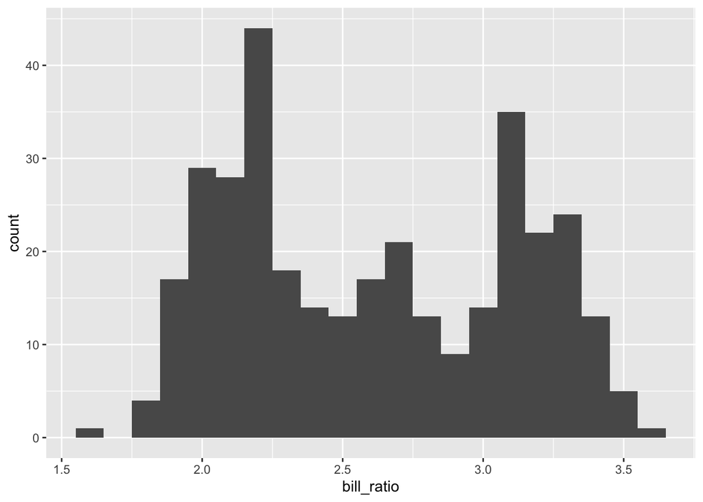

```r
penguins |> mutate(bill_ratio = bill_length_mm / bill_depth_mm) |>
  filter(!is.na(bill_ratio)) |>
  ggplot(aes(x = bill_ratio)) +
  geom_histogram(binwidth = 0.1)
```

Repeat that calculation for each species.

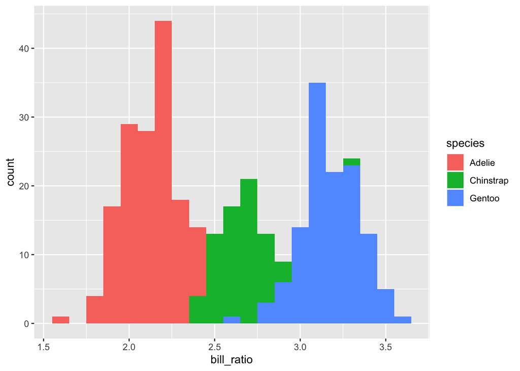

```r
penguins |>
  mutate(bill_ratio = bill_length_mm / bill_depth_mm) |>
  filter(!is.na(bill_ratio)) |>
  ggplot(aes(x = bill_ratio, fill = species)) +
  geom_histogram(binwidth = 0.1)
```

Compute the mean and standard deviation of body mass for each species and sex.